# COD_week4_2_MGK_BTE3207

Minsik Kim

2024-09-27

# Before begin..

Let’s load the SBP dataset.

```r
dataset_sbp <- read.csv(file = "Inha/5_Lectures/2024/Advanced biostatistics/scripts/BTE3207_Advanced_Biostatistics/dataset/sbp_dataset_korea_2013-2014.csv")

head(dataset_sbp)
```

```
##   SEX BTH_G SBP DBP FBS DIS  BMI
## 1   1     1 116  78  94   4 16.6
## 2   1     1 100  60  79   4 22.3
## 3   1     1 100  60  87   4 21.9
## 4   1     1 111  70  72   4 20.2
## 5   1     1 120  80  98   4 20.0
## 6   1     1 115  79  95   4 23.1
```

# The normal distribution

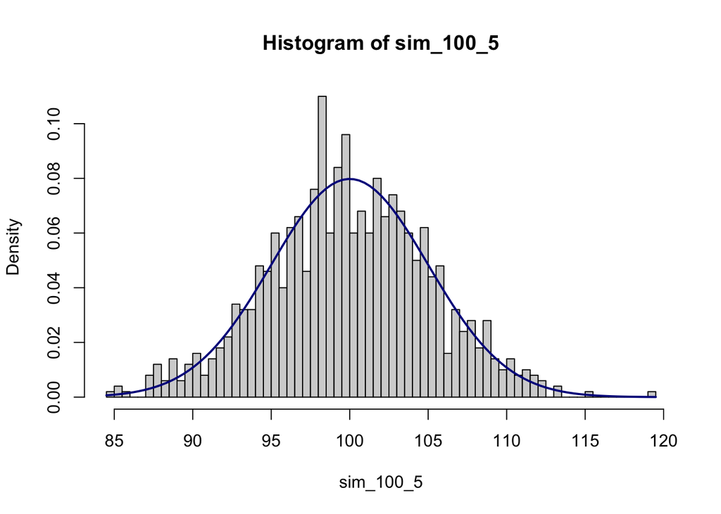

```r
set.seed(1)
sim_100_5 <- rnorm(1000, mean = 100, sd = 5) #makes a data with 1000 elements having mean of 100 and sd of 5

hist(sim_100_5, 100, probability = T) #how does it look like?
curve(dnorm(x, mean=100, sd=5),
      col="darkblue", lwd=2, add=TRUE, yaxt="n")
```

```r
mean(sim_100_5)
```

```
## [1] 99.94176
```

```r
sd(sim_100_5)
```

```
## [1] 5.174579
```

# normal distribution

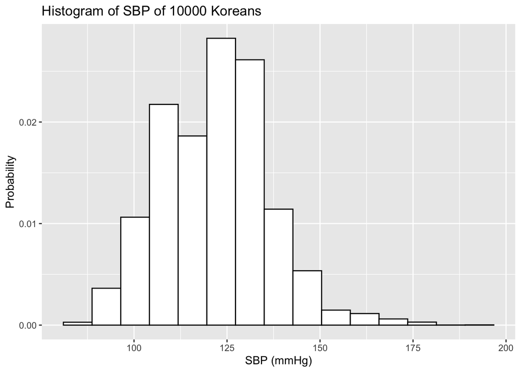

```r
set.seed(1)
sbp_10000 <- sample(dataset_sbp$SBP, 10000) %>%
        data.frame()

hist_sbp_10000 <- ggplot(data = sbp_10000) +
        geom_histogram(aes(x = .,
                           y =..density..),
                       bins = 15,
                       fill = "white",
                       col = "black") +
        ggtitle("Histogram of SBP of 10000 Koreans") +
        ylab("Probability") +
        xlab("SBP (mmHg)")

hist_sbp_10000
```

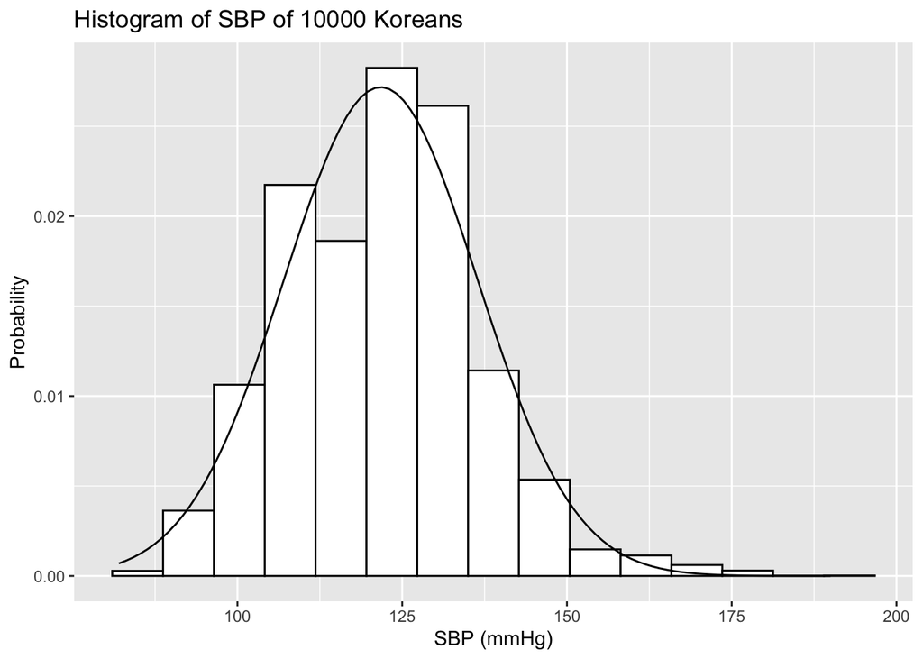

```r
hist_sbp_10000 +
        stat_function(fun = dnorm, args = list(mean = mean(sbp_10000$.), sd = sd(sbp_10000$.)))
```

```r
sbp_10000$. %>% mean
```

```
## [1] 121.7429
```

```r
sbp_10000$. %>% sd
```

```
## [1] 14.68246
```

```r
sbp_10000$. %>% median
```

```
## [1] 120
```

# z-score

```r
z_sbp_10000 <- (131-mean(sbp_10000$.))/sd(sbp_10000$.)

z_sbp_10000
```

```
## [1] 0.6304871
```

Here, the z-score of a person with SBP of 131 is 0.63.

Using this information, we cancalculate the percentile of him (assuming the SBP dataset is following the normal distribution)

```r
pnorm(z_sbp_10000)
```

```
## [1] 0.735812
```

It’s percentile is 73.6%.

Meanwhile, the actural 73.6th percentile of our dataset (sbp_10000) was 130. Why?

```r
quantile(sbp_10000$., 0.736)
```

```
## 73.6%
##   130
```

#Normalization

min-max normalization makes minimum vale to the 0 and maximum value to 1.

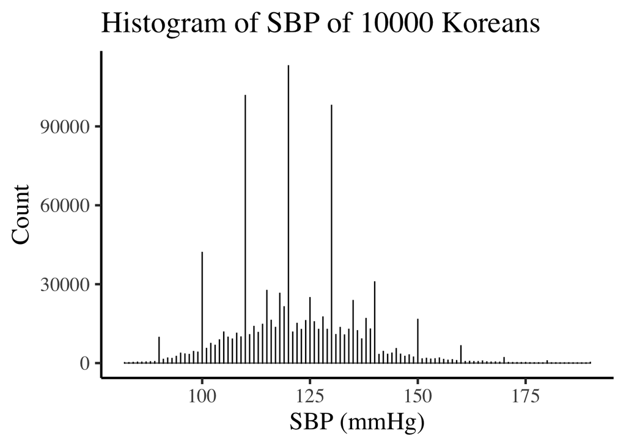

```r
dataset_sbp$norm_SBP <- (dataset_sbp$SBP - min(dataset_sbp$SBP))/
        (max(dataset_sbp$SBP) - min(dataset_sbp$SBP))


ggplot(data = dataset_sbp) +
        geom_histogram(aes(x = SBP,
                           y = ..count..),
                       binwidth = 0.01,
                       fill = "white",
                       col = "black") +
        ggtitle("Histogram of SBP of 10000 Koreans") +
        ylab("Count") +
        theme_classic(base_size = 20, base_family = "serif") +
        xlab("SBP (mmHg)")
```

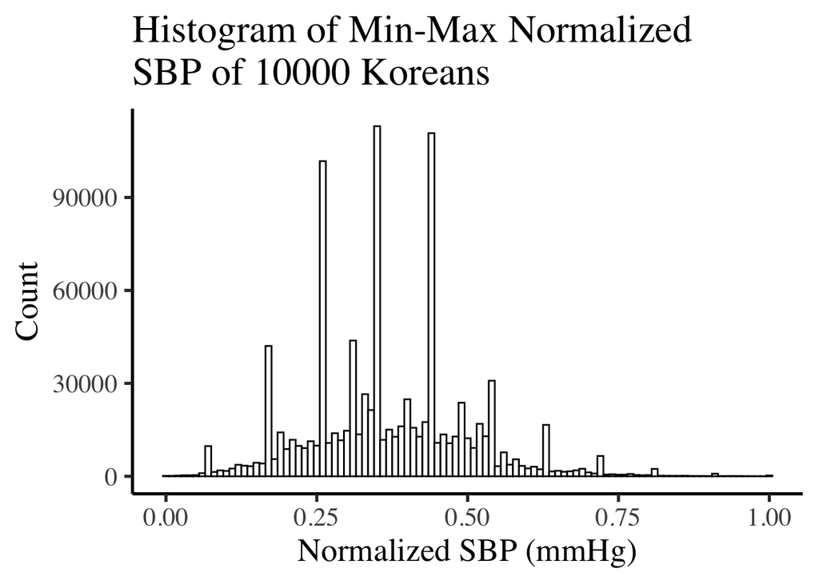

```r
ggplot(data = dataset_sbp) +
        geom_histogram(aes(x = norm_SBP,
                           y = ..count..),
                       binwidth = 0.01,
                       fill = "white",
                       col = "black") +
        ggtitle("Histogram of Min-Max Normalized\nSBP of 10000 Koreans") +
        ylab("Count") +
        theme_classic(base_size = 20, base_family = "serif") +
        xlab("Normalized SBP (mmHg)")
```

```r
#        stat_function(fun = dnorm, args = list(mean = mean(dataset_sbp$norm_SBP),
#                                               sd = sd(dataset_sbp$norm_SBP)))
```

# Standardization

Standardization makes mean to 0 and SD into 1.

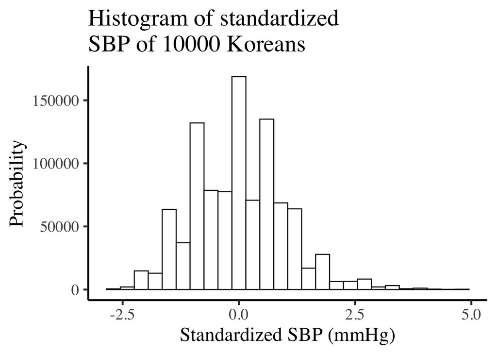

```r
dataset_sbp$std_SBP <- (dataset_sbp$SBP - mean(dataset_sbp$SBP))/
        sd(dataset_sbp$SBP)

ggplot(data = dataset_sbp) +
        geom_histogram(aes(x = std_SBP,
                           y = ..count..),
                       binwidth = 0.3,
                       fill = "white",
                       col = "black") +
        ggtitle("Histogram of standardized\nSBP of 10000 Koreans") +
        ylab("Probability") +
        xlab("Standardized SBP (mmHg)") +
        theme_classic(base_family = "serif", base_size = 20)
```

```r
        #stat_function(fun = dnorm, args = list(mean = mean(dataset_sbp$std_SBP), sd = sd(dataset_sbp$std_SBP)))
```

# Skewed data and z-score

We can calculate z-score of skewed data, but their calculation does not match with our assumption “the data is approximately normal”, therefore it results in wrong predictions.

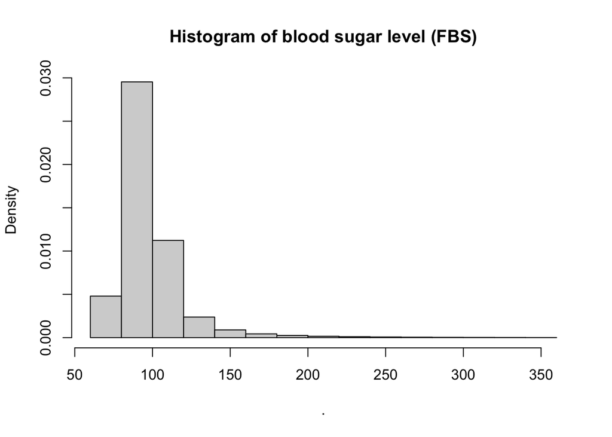

```r
dataset_sbp$FBS %>%
        hist(probability = T, main = "Histogram of blood sugar level (FBS)", 15)
```

```r
dataset_sbp$FBS %>% mean
```

```
## [1] 98.86443
```

```r
dataset_sbp$FBS %>% sd
```

```
## [1] 22.9813
```

```r
dataset_sbp$FBS %>% median
```

```
## [1] 94
```

So, if we use z-score to guess the 2.5% percentile’s FBS level,

```r
(dataset_sbp$FBS %>% mean) - 2 * (dataset_sbp$FBS %>% sd)
```

```
## [1] 52.90183
```

However, in actual database,

```r
quantile(dataset_sbp$FBS, 0.025)
```

```
## 2.5%
##   74
```

Thee z-score cannot represent the actual dataset.

# Bibliography

[output not shown]